# PA_healthinsurance

2024-01-27

```r
# Run once if these packages aren't installed
install.packages(c("tidyverse", "corrplot", "hexbin", "e1071", "shiny"))
```

```r
library(tidyverse)
# data/health_insurance.csv is the same data as the original health_insurance.RData
data <- read.csv("data/health_insurance.csv") %>%
  mutate_if(is.character, as.factor)

data %>%
  summary()
```

```
##       age            sex           bmi           children     smoker
##  Min.   :18.00   female:662   Min.   :15.96   Min.   :0.000   no :1064
##  1st Qu.:27.00   male  :676   1st Qu.:26.30   1st Qu.:0.000   yes: 274
##  Median :39.00                Median :30.40   Median :1.000
##  Mean   :39.21                Mean   :30.66   Mean   :1.095
##  3rd Qu.:51.00                3rd Qu.:34.69   3rd Qu.:2.000
##  Max.   :64.00                Max.   :53.13   Max.   :5.000
##        region       charges
##  northeast:324   Min.   : 1122
##  northwest:325   1st Qu.: 4740
##  southeast:364   Median : 9382
##  southwest:325   Mean   :13270
##                  3rd Qu.:16640
##                  Max.   :63770
```

First, gather some basic data about the population:

The total number of people in this dataset is 1338 with 662 females and 676 males. Our youngest individual is 18 years of age whereas our oldest individual is 64. The max amount of children someone has is 5 whereas the lowest number of children one could have is 0. There are 1064 people who are non-smokers and 274 who are smokers. The lowest BMI is 15.96 and the highest BMI is 53.13. There are 324 from the Northeast region, 325 from the Northwest, 364 from the Southeast and 325 from the Southwest. The average charge per individual is 13,270.

If we wanted, we could also just manually find these values by performing functions on the dataset itself. The number of people is the number of rows:

```r
n <- nrow(data)
n
```

```
## [1] 1338
```

The minimum age is

```r
min <- min(data$age)
min
```

```
## [1] 18
```

whereas the maximum age is

```r
max<- max(data$age)
max
```

```
## [1] 64
```

We can use table function to quickly find the number of males and females

```r
table(data$sex)
```

```
##
## female   male
##    662    676
```

Or we can use the dplyr function from the tidyverse package

```r
library(tidyverse)
data %>% count(sex)
```

| sex | n |
| --- | --- |
| female | 662 |
| male | 676 |

We can perform similar functions for both the smoker and region subpopulations

```r
data %>% count(smoker)
```

| smoker | n |
| --- | --- |
| no | 1064 |
| yes | 274 |

```r
data %>% count(region)
```

| region | n |
| --- | --- |
| northeast | 324 |
| northwest | 325 |
| southeast | 364 |
| southwest | 325 |

If we want to narrow it down to the number of men or number of women per region we can simply add on new arguments

```r
data %>% count(region,sex)
```

| region | sex | n |
| --- | --- | --- |
| northeast | female | 161 |
| northeast | male | 163 |
| northwest | female | 164 |
| northwest | male | 161 |
| southeast | female | 175 |
| southeast | male | 189 |
| southwest | female | 162 |
| southwest | male | 163 |

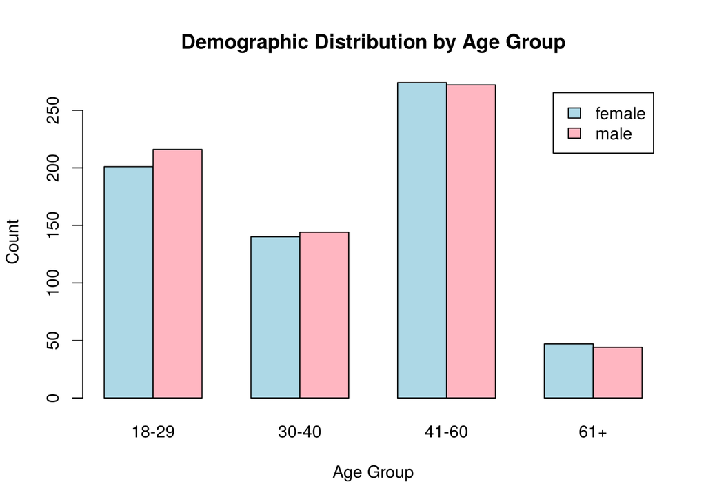

```r
# Count of individuals by sex and age group
data$age_group <- cut(data$age, breaks = c(17, 29, 40, 60, Inf), labels = c("18-29", "30-40", "41-60", "61+"))
demographic_counts <- table(data$sex, data$age_group)

# Visualize with a bar plot
barplot(demographic_counts, beside = TRUE, col = c("lightblue", "lightpink"),
        main = "Demographic Distribution by Age Group", xlab = "Age Group", ylab = "Count", legend = TRUE)
```

Similarily for men who are smokers with children

```r
data_men <- data %>%
  filter(sex == "male")
data_men %>% count(children,smoker,)
```

| children | smoker | n |
| --- | --- | --- |
| 0 | no | 223 |
| 0 | yes | 62 |
| 1 | no | 130 |
| 1 | yes | 36 |
| 2 | no | 88 |
| 2 | yes | 33 |
| 3 | no | 55 |
| 3 | yes | 25 |
| 4 | no | 11 |
| 4 | yes | 3 |

[output cut: 1 more lines]

We want to visualize a range of values for BMI thus let’s using a histogram

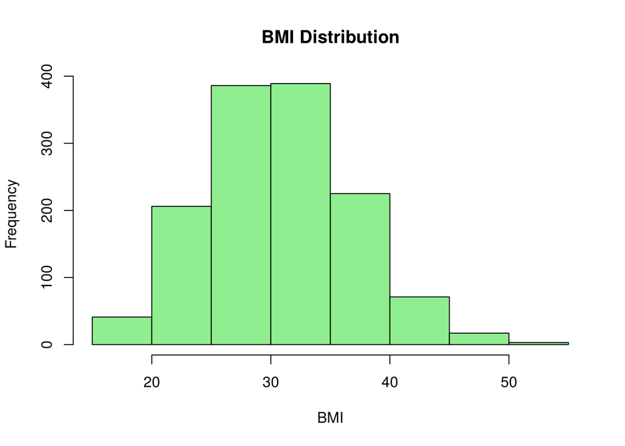

```r
hist(data$bmi, col= "lightgreen", main="BMI Distribution", xlab = "BMI")
```

From this plot we can see that the highest frequencies are at a BMI centered around 30

Similarily for age:

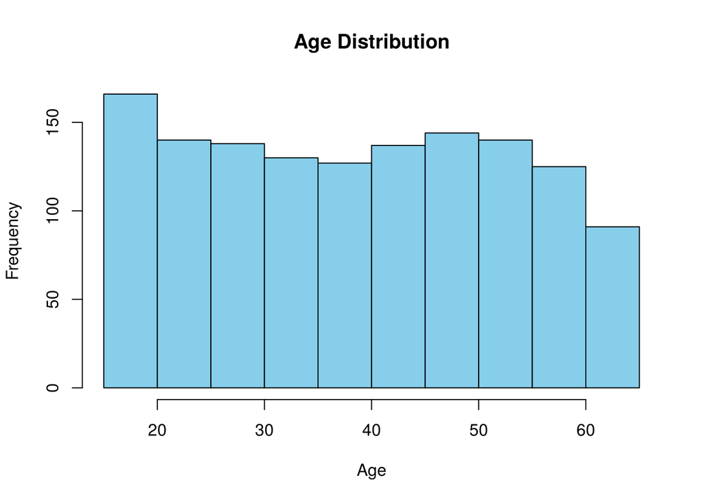

```r
hist(data$age, col = "skyblue", main = "Age Distribution", xlab = "Age")
```

To find out how many male/females at each age:

```r
number_of_male_female <- data %>% count(age,sex)
number_of_male_female
```

| age | sex | n |
| --- | --- | --- |
| 18 | female | 33 |
| 18 | male | 36 |
| 19 | female | 33 |
| 19 | male | 35 |
| 20 | female | 14 |
| 20 | male | 15 |
| 21 | female | 13 |
| 21 | male | 15 |
| 22 | female | 13 |
| 22 | male | 15 |

[output cut: 84 more lines]

Or we could do it based on age ranges

```r
# data %>% count(age %in% 18:25, sex)
age_groups <- data %>%
  mutate(age_group = case_when(
    age %in% 18:29 ~ '18-29',
    age %in% 30:40 ~ '30-40',
    age %in% 41:60 ~ '41-60',
    age >= 61 ~ '61+'
  )) %>%
  count(age_group, sex)

print(age_groups)
```

```
##   age_group    sex   n
## 1     18-29 female 201
## 2     18-29   male 216
## 3     30-40 female 140
## 4     30-40   male 144
## 5     41-60 female 274
## 6     41-60   male 272
## 7       61+ female  47
## 8       61+   male  44
```

```r
data_age_groups <- as.data.frame(age_groups)
```

Plotting the data onto a barplot:

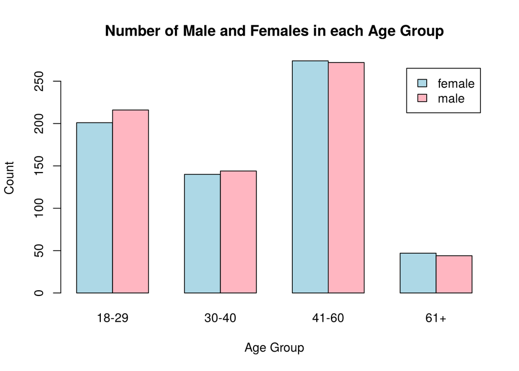

```r
barplot(demographic_counts, beside = TRUE, col = c("lightblue", "lightpink"),
        main = "Number of Male and Females in each Age Group", xlab = "Age Group", ylab = "Count", legend = TRUE)
```

We can also use ggplot2 to plot the data out:

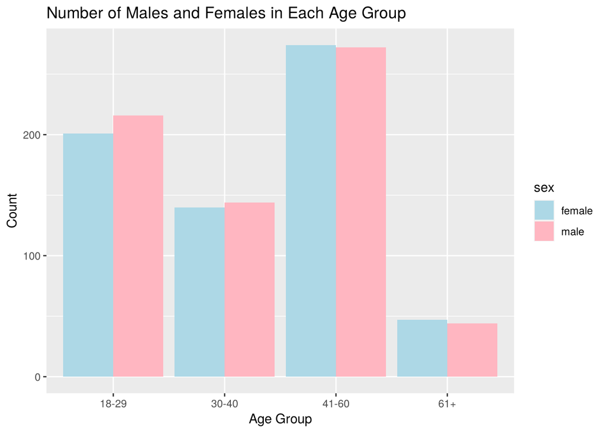

```r
library(ggplot2)
ggplot(data_age_groups, aes(x = age_group, y = n, fill = sex)) +
  geom_bar(stat = "identity", position = "dodge") +
  labs(title = "Number of Males and Females in Each Age Group",
       x = "Age Group", y = "Count") +
  scale_fill_manual(values = c("lightblue", "lightpink"))
```

We want to see if there exists correlation between our variables so let’s create a correlation matrix:

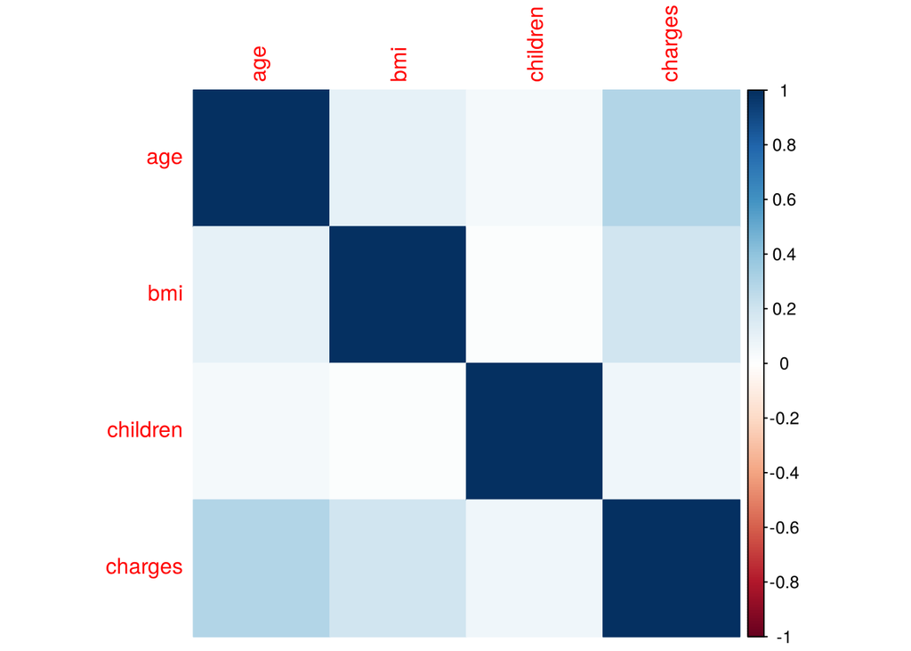

```r
library(corrplot)
cor_matrix <- cor(data[, c("age", "bmi", "children", "charges")])
corrplot(cor_matrix, method = "color")
```

```r
round(cor_matrix, 2)
```

```
##           age  bmi children charges
## age      1.00 0.11     0.04    0.30
## bmi      0.11 1.00     0.01    0.20
## children 0.04 0.01     1.00    0.07
## charges  0.30 0.20     0.07    1.00
```

From this matrix we can infer a few things:

1. All correlations are positive, but most are weak.
2. Age and charges have the strongest correlation, at about 0.30, followed by BMI and charges at about 0.20.
3. Age and BMI are barely correlated (about 0.11), and the number of children is almost unrelated to everything else.

These are simple pairwise correlations. They don’t account for smoking, which turns out to matter far more than any of these variables (see below).

## Relationship between Smoking and Charges

To see the relationship between smoking and charges, we can compare summary statistics and perform a t-test:

```r
summary(data$charges[data$smoker == "yes"])
```

```
##    Min. 1st Qu.  Median    Mean 3rd Qu.    Max.
##   12829   20826   34456   32050   41019   63770
```

```r
summary(data$charges[data$smoker == "no"])
```

```
##    Min. 1st Qu.  Median    Mean 3rd Qu.    Max.
##    1122    3986    7345    8434   11363   36911
```

From a quick glance we can see that on average, non-smokers paid less on average for insurance charges

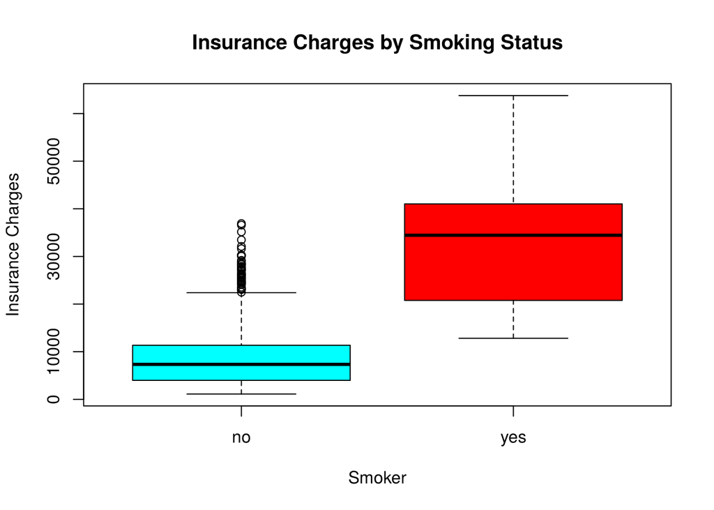

```r
boxplot(data$charges ~ data$smoker, col = c("cyan", "red"),
        main = "Insurance Charges by Smoking Status", xlab = "Smoker", ylab = "Insurance Charges")
```

```r
results<-t.test(data$charges[data$smoker == "yes"], data$charges[data$smoker == "no"])
print(results)
```

```
##
##  Welch Two Sample t-test
##
## data:  data$charges[data$smoker == "yes"] and data$charges[data$smoker == "no"]
## t = 32.752, df = 311.85, p-value < 2.2e-16
## alternative hypothesis: true difference in means is not equal to 0
## 95 percent confidence interval:
##  22197.21 25034.71
## sample estimates:
## mean of x mean of y
## 32050.232  8434.268
```

At first glance, our t-value is large, which suggests a large difference between the mean charges of smokers and non-smokers. Note that it is positive which implies that the smokers on average have a greater charge than non-smokers. The p-value is far below 0.05, so smokers have significantly higher average charges than non-smokers. (This is Welch’s t-test, which doesn’t assume the two groups have equal variances. That matters here, since smokers’ charges are much more spread out.)

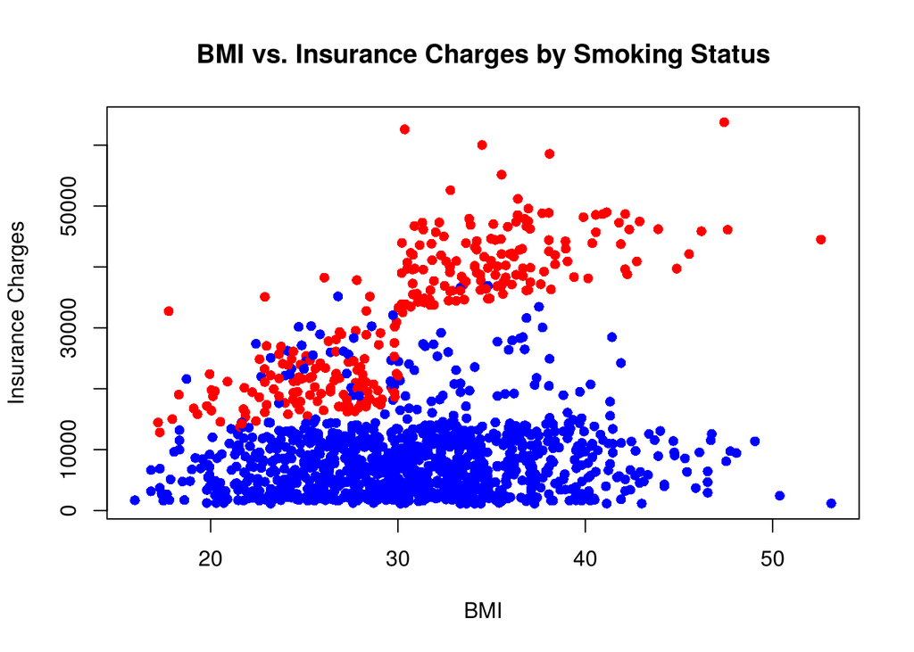

```r
plot(data$bmi, data$charges, col = ifelse(data$smoker == "yes", "red", "blue"),
     pch = 16, main = "BMI vs. Insurance Charges by Smoking Status", xlab = "BMI", ylab = "Insurance Charges")
```

We can see from this scatterplot that the spread of BMI was roughly equal for smokers (red) and non-smokers (blue). The insurance charges for smokers was overall higher across the board, with a spike in distribution once BMI was greater than 30

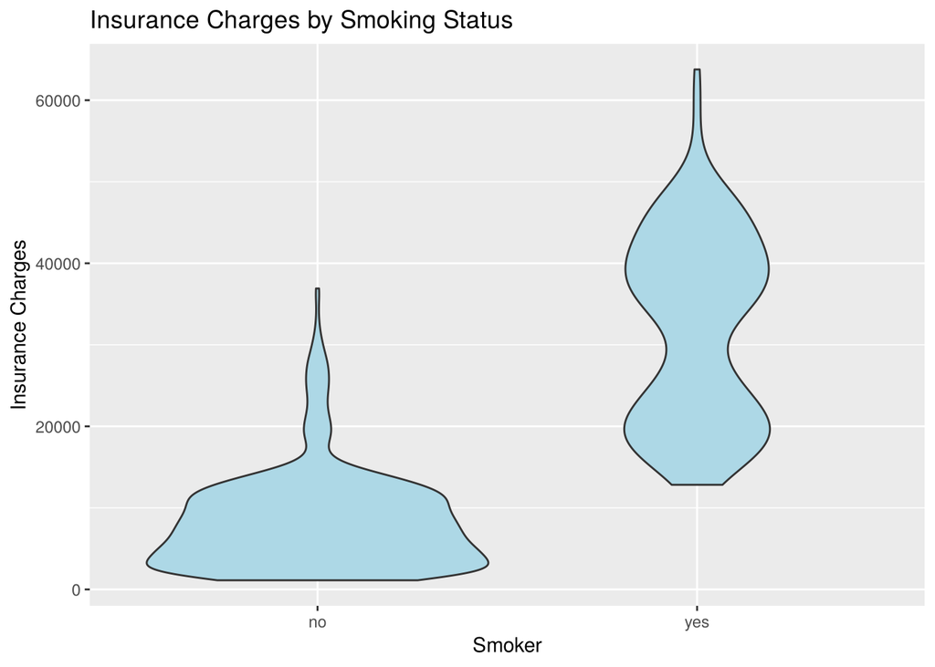

```r
library(ggplot2)
ggplot(data, aes(x = smoker, y = charges)) +
  geom_violin(fill = "lightblue") +
  labs(title = "Insurance Charges by Smoking Status", x = "Smoker", y = "Insurance Charges")
```

## Relationship between BMI and charges

```r
summary(data$charges)
```

```
##    Min. 1st Qu.  Median    Mean 3rd Qu.    Max.
##    1122    4740    9382   13270   16640   63770
```

```r
summary(data$bmi)
```

```
##    Min. 1st Qu.  Median    Mean 3rd Qu.    Max.
##   15.96   26.30   30.40   30.66   34.69   53.13
```

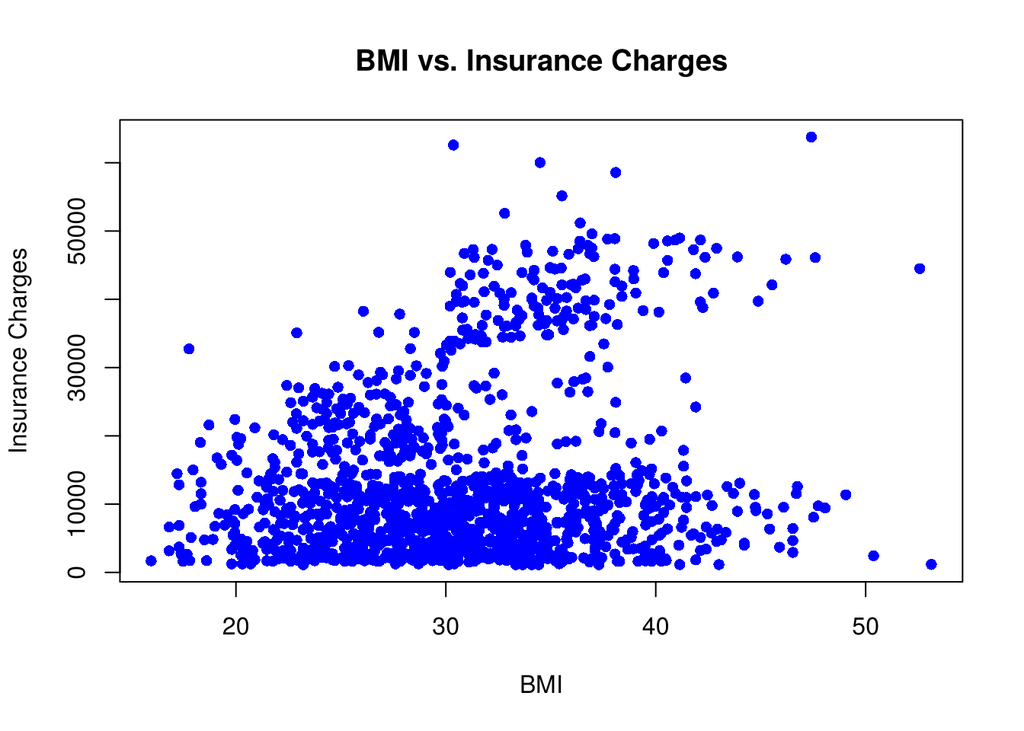

```r
plot(data$bmi, data$charges, col = "blue", pch = 16,
     main = "BMI vs. Insurance Charges", xlab = "BMI", ylab = "Insurance Charges")
```

```r
cor(data$bmi, data$charges)
```

```
## [1] 0.198341
```

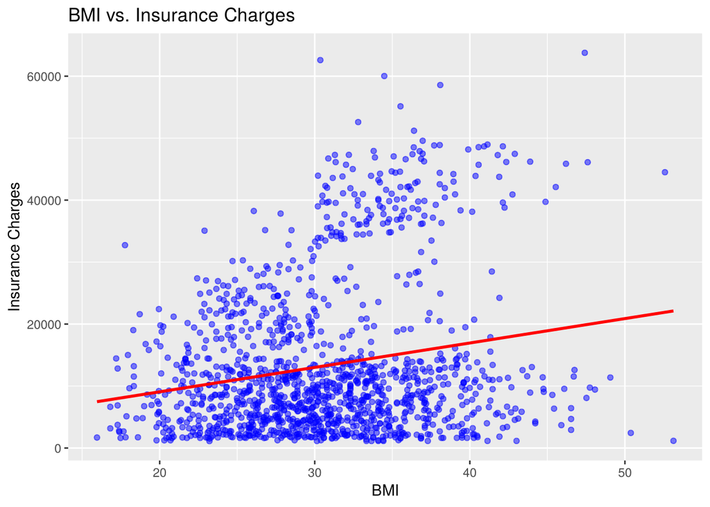

```r
library(ggplot2)
ggplot(data, aes(x = bmi, y = charges)) +
  geom_point(color = "blue", alpha = 0.5) +
  geom_smooth(method = "lm", se = FALSE, color = "red") +
  labs(title = "BMI vs. Insurance Charges", x = "BMI", y = "Insurance Charges")
```

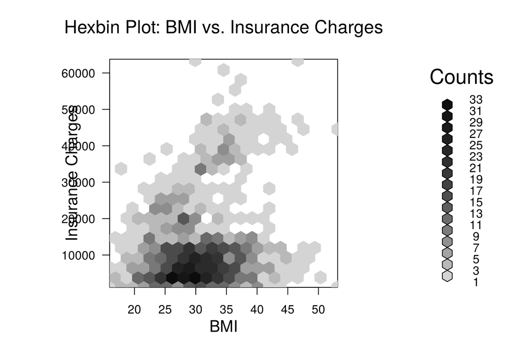

```r
library(hexbin)
hb <- hexbin(data$bmi, data$charges, xbins = 20)
plot(hb, main = "Hexbin Plot: BMI vs. Insurance Charges", xlab = "BMI", ylab = "Insurance Charges")
```

```r
cor.test(data$bmi, data$charges, method = "pearson")
```

```
##
##  Pearson's product-moment correlation
##
## data:  data$bmi and data$charges
## t = 7.3966, df = 1336, p-value = 2.459e-13
## alternative hypothesis: true correlation is not equal to 0
## 95 percent confidence interval:
##  0.1463052 0.2492822
## sample estimates:
##      cor
## 0.198341
```

```r
lm_model <- lm(charges ~ bmi, data = data)
summary(lm_model)
```

```
##
## Call:
## lm(formula = charges ~ bmi, data = data)
##
## Residuals:
##    Min     1Q Median     3Q    Max
## -20956  -8118  -3757   4722  49442
##
## Coefficients:
##             Estimate Std. Error t value Pr(>|t|)
## (Intercept)  1192.94    1664.80   0.717    0.474
## bmi           393.87      53.25   7.397 2.46e-13 ***
## ---
## Signif. codes:  0 '***' 0.001 '**' 0.01 '*' 0.05 '.' 0.1 ' ' 1
##
## Residual standard error: 11870 on 1336 degrees of freedom
## Multiple R-squared:  0.03934,    Adjusted R-squared:  0.03862
## F-statistic: 54.71 on 1 and 1336 DF,  p-value: 2.459e-13
```

Since our dataset is large, we can use a hexbin plot to further analyze the distribution. We can see that at a BMI of ~28-30, we have the highest density of people with insurance charges less than 10000.

## Relationship between Age and Charges

Let’s determine if there exists a relation between the age of an individual and the amount of their charges

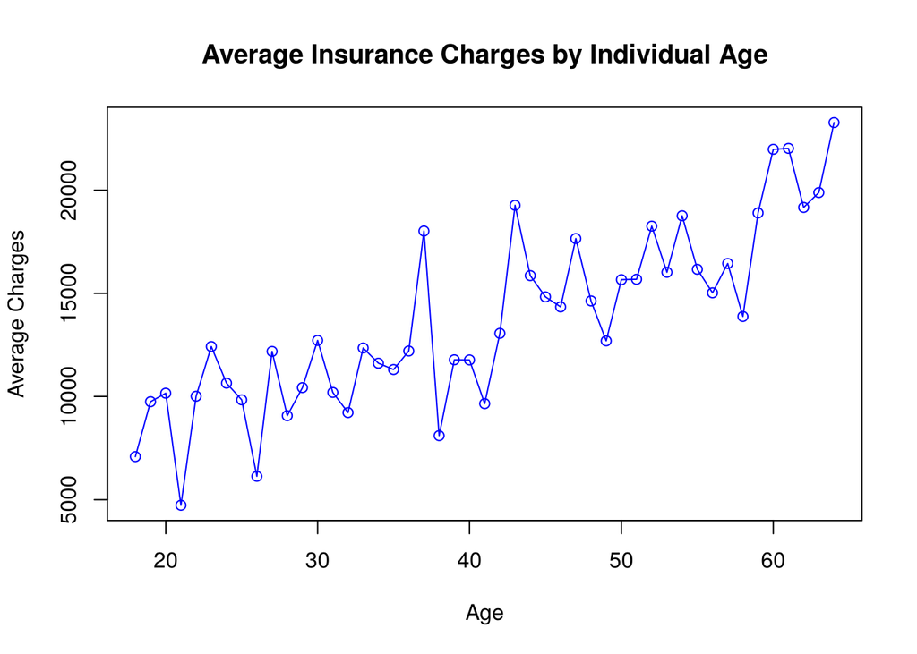

```r
avg_charges_by_age <- tapply(data$charges, data$age, mean)

plot(names(avg_charges_by_age), avg_charges_by_age, type = "o", col = "blue",
     main = "Average Insurance Charges by Individual Age", xlab = "Age", ylab = "Average Charges")
```

We use an O plot here instead of a B plot to better see the trends

Note if we fit a trend line to the plot:

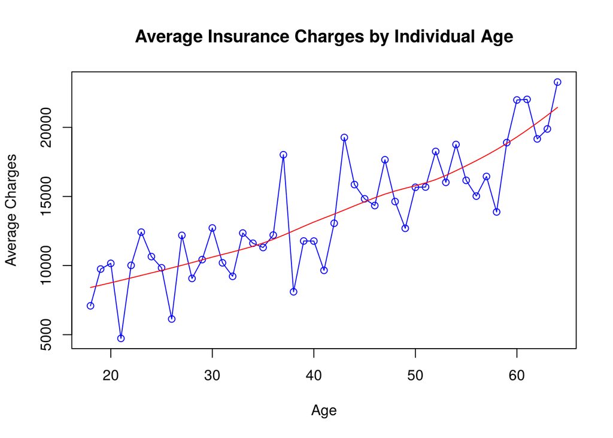

```r
plot(names(avg_charges_by_age), avg_charges_by_age, type = "o", col = "blue",
     main = "Average Insurance Charges by Individual Age", xlab = "Age", ylab = "Average Charges")
loess_model <- loess(avg_charges_by_age ~ as.numeric(names(avg_charges_by_age)))
lines(as.numeric(names(avg_charges_by_age)), predict(loess_model), col = "red")
```

Here, it is evident that there is a positive trend with charges regarding age.

Let’s generalize the data more into age groups instead of individual ages:

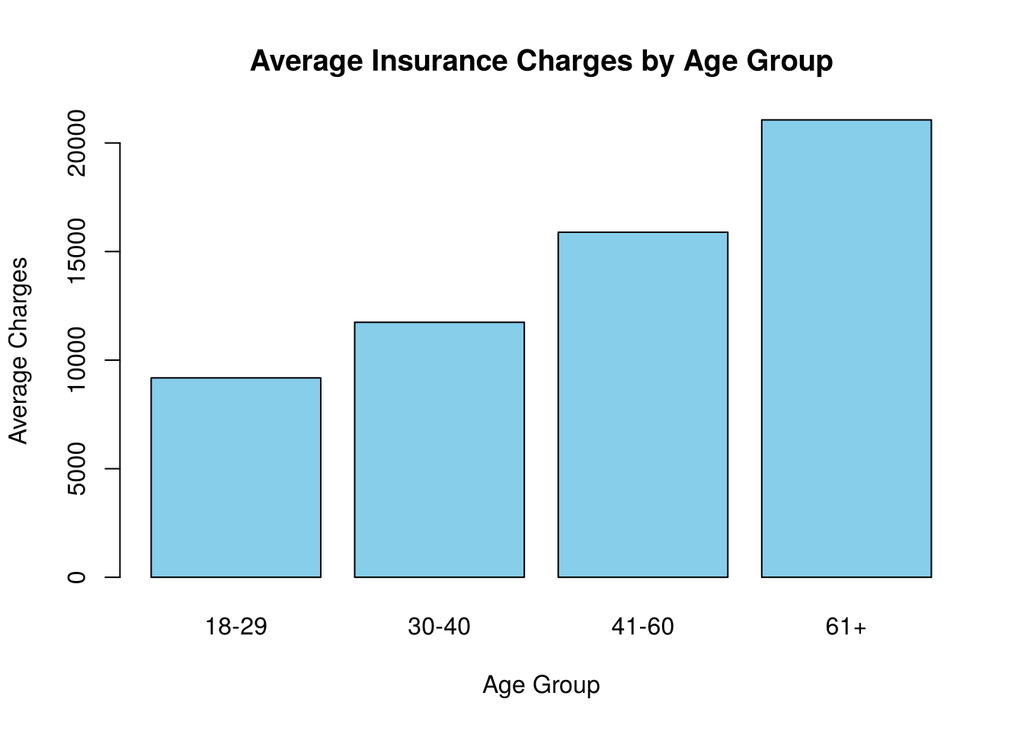

```r
avg_charges_by_age_group <- tapply(data$charges, data$age_group, mean)

barplot(avg_charges_by_age_group, col = "skyblue",
        main = "Average Insurance Charges by Age Group", xlab = "Age Group", ylab = "Average Charges")
```

Here, it is evident the older age groups spend more on charges than the groups previous to them

Suppose we want to predict what the insurance charges would be based on one’s BMI alone.

```r
pred_charge <- lm(charges ~ bmi, data = data)
summary(pred_charge)
```

```
##
## Call:
## lm(formula = charges ~ bmi, data = data)
##
## Residuals:
##    Min     1Q Median     3Q    Max
## -20956  -8118  -3757   4722  49442
##
## Coefficients:
##             Estimate Std. Error t value Pr(>|t|)
## (Intercept)  1192.94    1664.80   0.717    0.474
## bmi           393.87      53.25   7.397 2.46e-13 ***
## ---
## Signif. codes:  0 '***' 0.001 '**' 0.01 '*' 0.05 '.' 0.1 ' ' 1
##
## Residual standard error: 11870 on 1336 degrees of freedom
## Multiple R-squared:  0.03934,    Adjusted R-squared:  0.03862
## F-statistic: 54.71 on 1 and 1336 DF,  p-value: 2.459e-13
```

BMI alone explains only about 4% of the variation in charges (R-squared). Adding sex makes almost no difference:

```r
summary(lm(charges ~ bmi + sex, data = data))$adj.r.squared
```

```
## [1] 0.04022151
```

## Relationship between Region and Charges

Let us see if there exists a relation between the region an individual inhabits and the charges they possess

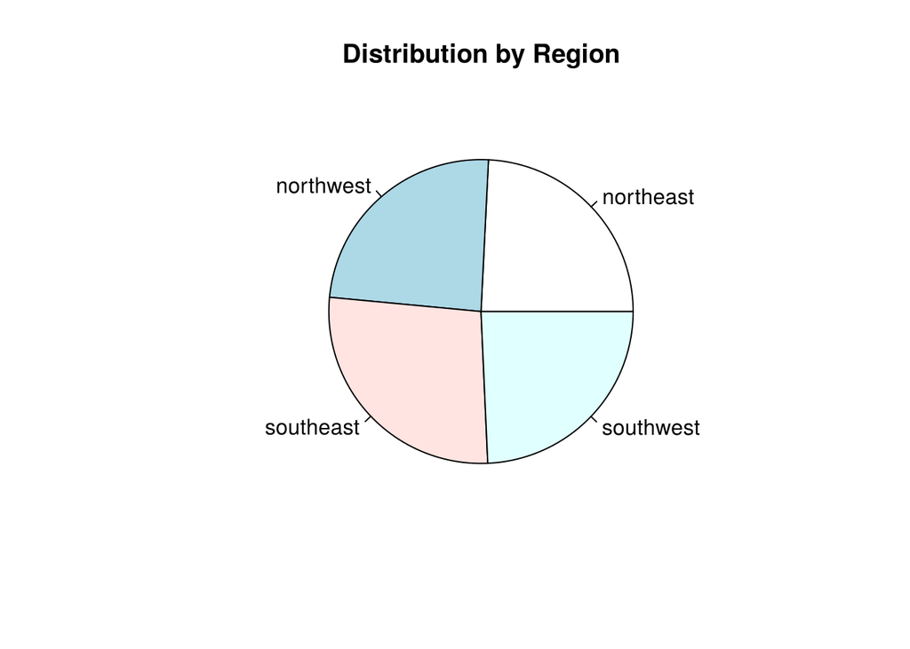

```r
region_counts <- table(data$region)

pie(region_counts, labels = names(region_counts), main = "Distribution by Region")
```

From this pie chart, we can see each region roughly holds an equivalent portion

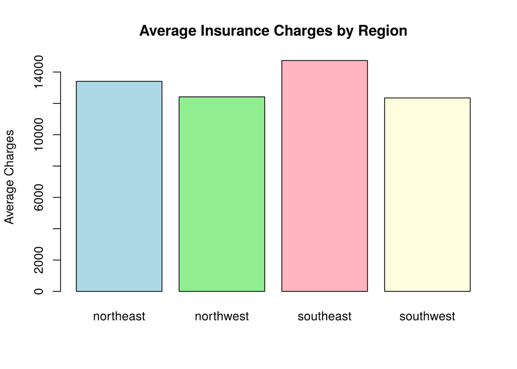

```r
avg_charges_by_region <- tapply(data$charges, data$region, mean)

barplot(avg_charges_by_region, col = c("lightblue", "lightgreen", "lightpink", "lightyellow"),
        main = "Average Insurance Charges by Region", ylab = "Average Charges")
```

At a quick glance, the southeast region seems to have the highest average charges, followed by the northeast and finally the northwest and southwest. To get further information, let’s perform an ANOVA test

```r
anova_result <- aov(charges ~ region, data = data)

summary(anova_result)
```

```
##               Df    Sum Sq   Mean Sq F value Pr(>F)
## region         3 1.301e+09 433586560    2.97 0.0309 *
## Residuals   1334 1.948e+11 146007093
## ---
## Signif. codes:  0 '***' 0.001 '**' 0.01 '*' 0.05 '.' 0.1 ' ' 1
```

Note here out p value is less than 0.05 and our F-value is 2.97, hence this suggests that we reject our null hypothesis of the means among the regions being equal and that there exists a significant difference in means between at least one of the regions

```r
tukey_results <- TukeyHSD(anova_result)
print(tukey_results)
```

```
##   Tukey multiple comparisons of means
##     95% family-wise confidence level
##
## Fit: aov(formula = charges ~ region, data = data)
##
## $region
##                           diff         lwr        upr     p adj
## northwest-northeast  -988.8091 -3428.93434 1451.31605 0.7245243
## southeast-northeast  1329.0269 -1044.94167 3702.99551 0.4745046
## southwest-northeast -1059.4471 -3499.57234 1380.67806 0.6792086
## southeast-northwest  2317.8361   -54.19944 4689.87157 0.0582938
## southwest-northwest   -70.6380 -2508.88256 2367.60656 0.9998516
## southwest-southeast -2388.4741 -4760.50957  -16.43855 0.0476896
```

We can see from our Tukey test that the adjusted p-value for the southwest vs southeast comparison is just below 0.05 (0.048), so those means are significantly different. Southeast vs northwest is just above (0.058), and the other pairs are far from significant.

Charges are very skewed and far more spread out for smokers, which strains ANOVA’s equal-variance assumption, so treat these p-values as approximate. More importantly, the regions differ in who lives there:

```r
data %>%
  group_by(region) %>%
  summarise(share_smokers = mean(smoker == "yes"), mean_bmi = mean(bmi), mean_charges = mean(charges))
```

| region | share_smokers | mean_bmi | mean_charges |
| --- | --- | --- | --- |
| northeast | 0.2067901 | 29.17350 | 13406.38 |
| northwest | 0.1784615 | 29.19978 | 12417.58 |
| southeast | 0.2500000 | 33.35599 | 14735.41 |
| southwest | 0.1784615 | 30.59662 | 12346.94 |

The southeast has the highest share of smokers and the highest average BMI. That alone could explain its higher average charges, which we check in the regression below.

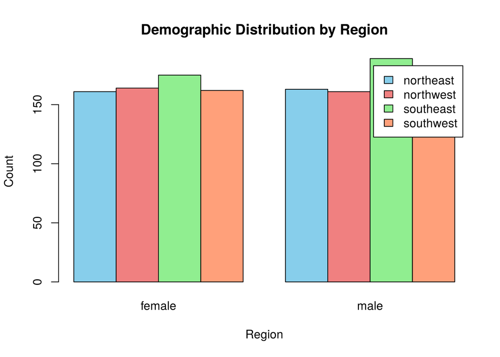

```r
demographic_counts_by_region <- table(data$region, data$sex)

col_palette <- c("skyblue", "lightcoral", "lightgreen", "lightsalmon")

barplot(demographic_counts_by_region, beside = TRUE, col = col_palette,
        main = "Demographic Distribution by Region", xlab = "Region", ylab = "Count", legend = TRUE)
```

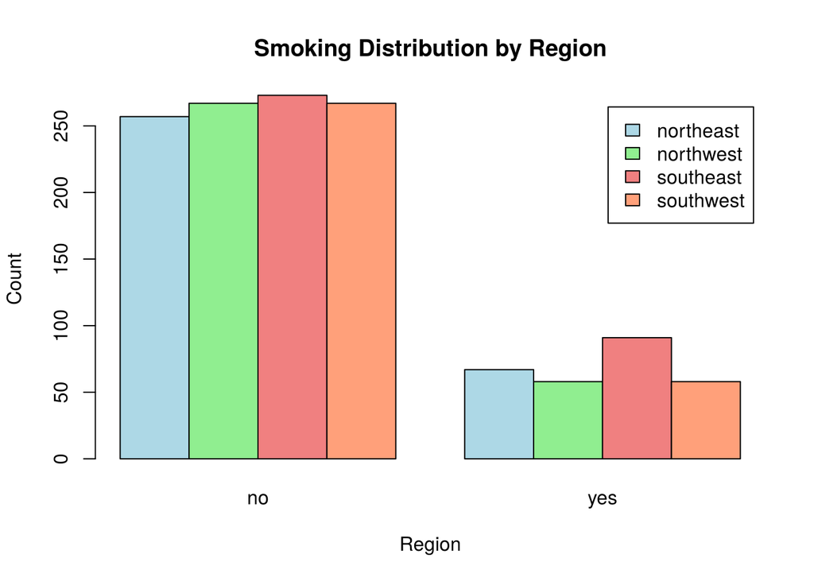

```r
smoking_counts_by_region <- table(data$region, data$smoker)

col_palette <- c("lightblue", "lightgreen", "lightcoral", "lightsalmon")

barplot(smoking_counts_by_region, beside = TRUE, col = col_palette,
        main = "Smoking Distribution by Region", xlab = "Region", ylab = "Count", legend = TRUE)
```

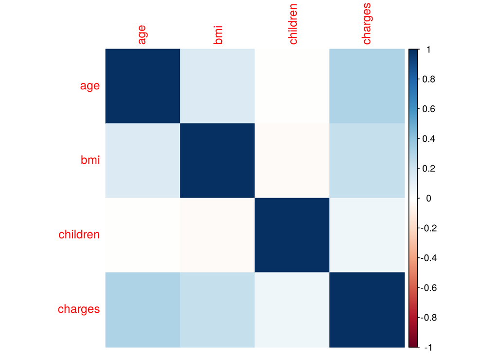

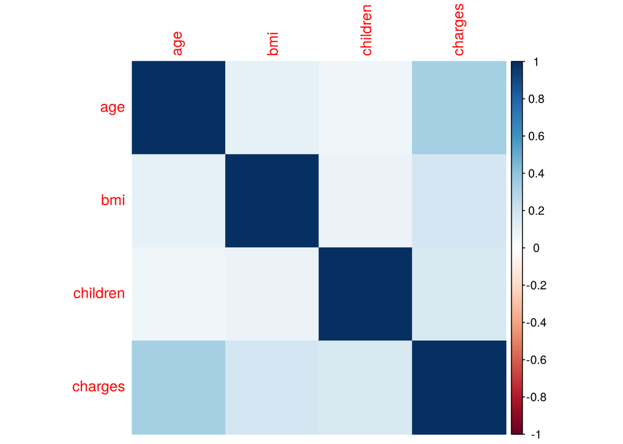

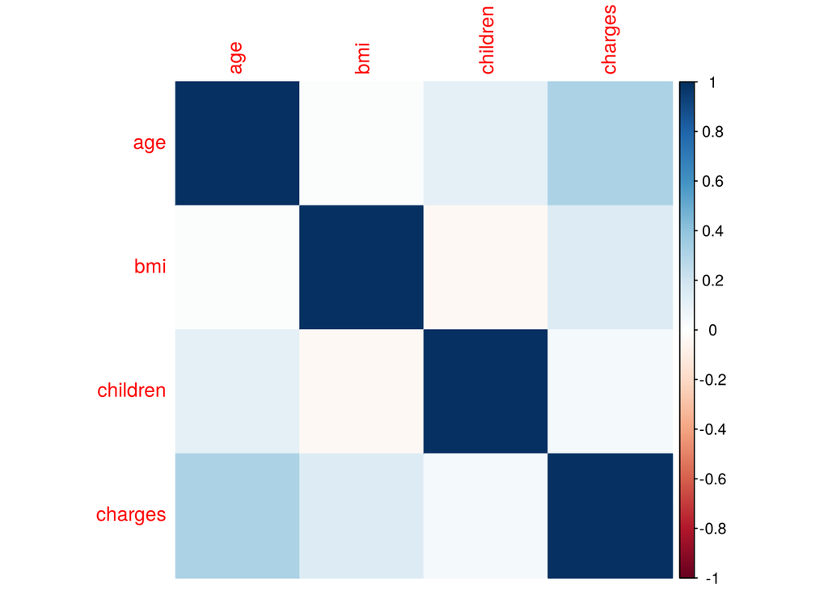

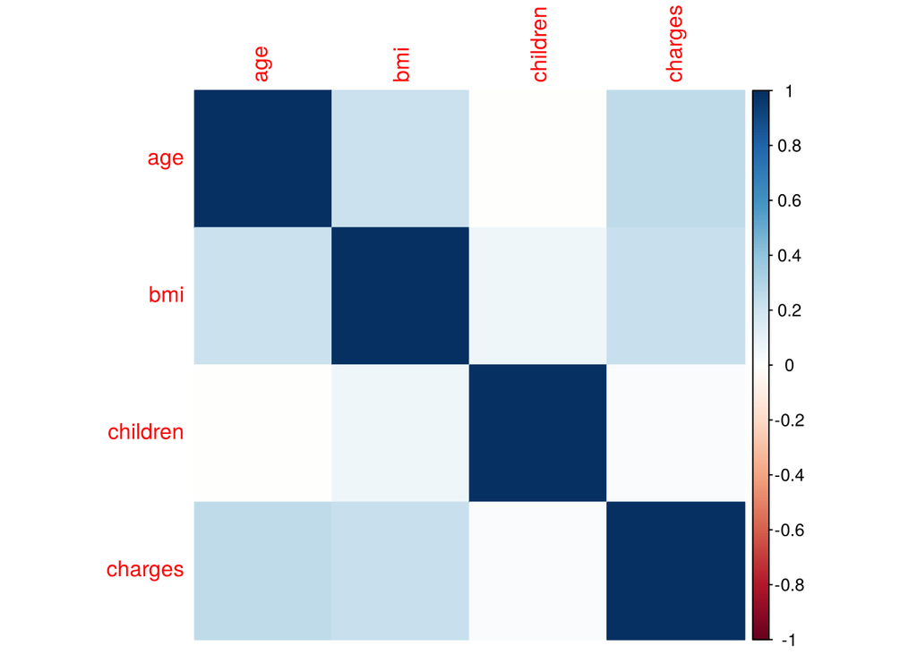

[output not shown]

[output cut: 74 more lines]

[output not shown]

```r
library(corrplot)
data_by_region <- split(data, data$region)

correlation_matrices <- lapply(data_by_region, function(subdata) cor(subdata[, c("age", "bmi", "children", "charges")]))

lapply(correlation_matrices, function(cor_matrix) corrplot(cor_matrix, method = "color"))
```

## Predicting Charges of an Individual

Given the age,sex,BMI, number of children, if they are a smoker, and the region they are from, we want to be able to predict the charges that an individual would have. We will perform regression analysis:

```r
# Here we are converting variables sex and smoker into factors
data$sex <- as.factor(data$sex)
data$smoker <- as.factor(data$smoker)

data2 <- cbind(data, model.matrix(~ region - 1, data = data))
model <- lm(charges ~ age + sex + bmi + children + smoker + region, data = data2)
summary(model)
```

```
##
## Call:
## lm(formula = charges ~ age + sex + bmi + children + smoker +
##     region, data = data2)
##
## Residuals:
##      Min       1Q   Median       3Q      Max
## -11304.9  -2848.1   -982.1   1393.9  29992.8
##
## Coefficients:
##                 Estimate Std. Error t value Pr(>|t|)
## (Intercept)     -11938.5      987.8 -12.086  < 2e-16 ***
## age                256.9       11.9  21.587  < 2e-16 ***
## sexmale           -131.3      332.9  -0.394 0.693348
## bmi                339.2       28.6  11.860  < 2e-16 ***
## children           475.5      137.8   3.451 0.000577 ***
## smokeryes        23848.5      413.1  57.723  < 2e-16 ***
## regionnorthwest   -353.0      476.3  -0.741 0.458769
## regionsoutheast  -1035.0      478.7  -2.162 0.030782 *
## regionsouthwest   -960.0      477.9  -2.009 0.044765 *
## ---
## Signif. codes:  0 '***' 0.001 '**' 0.01 '*' 0.05 '.' 0.1 ' ' 1
##
## Residual standard error: 6062 on 1329 degrees of freedom
## Multiple R-squared:  0.7509, Adjusted R-squared:  0.7494
## F-statistic: 500.8 on 8 and 1329 DF,  p-value: < 2.2e-16
```

Our intercept estimate is -11938.5, we can ignore this since this is the expected value when all other variables are 0 hence this is redundant. The age estimate is 256.9 which means that the charges are estimated to be increased by 256.9 for every additional unit of age (year). The sexmale estimate is -131.3 which would normally suggest that the charges for males are lower but since our p-value is greater than 0.05, we can conclude this variable is not statistically significant. The BMI estimate is 339.2 which means that for every unit increase in BMI, the charges increase by 339.2. The children estimate is 475.5 which means for every additional child an individual has, the charges increases by 475.5. For the smokeryes variable, this has an estimate of 23848.5 with a very small p-value. This means that if an individual is a smoker, then their charges are estimated to increase by 23848.5, by far the largest margin of the variables so far.

We can see that the southeast region has an estimate of -1035 compared to our northeast region, which seems to contradict our previous barplot. It doesn’t: the barplot compared raw averages, while the regression compares people with the same age, BMI, children and smoking status. The southeast’s higher raw average comes from its higher share of smokers and higher BMI (confounding). Once those are held constant, living in the southeast is associated with slightly lower charges.

Next, we check the model’s assumptions: normality of residuals and constant variance (homoscedasticity).

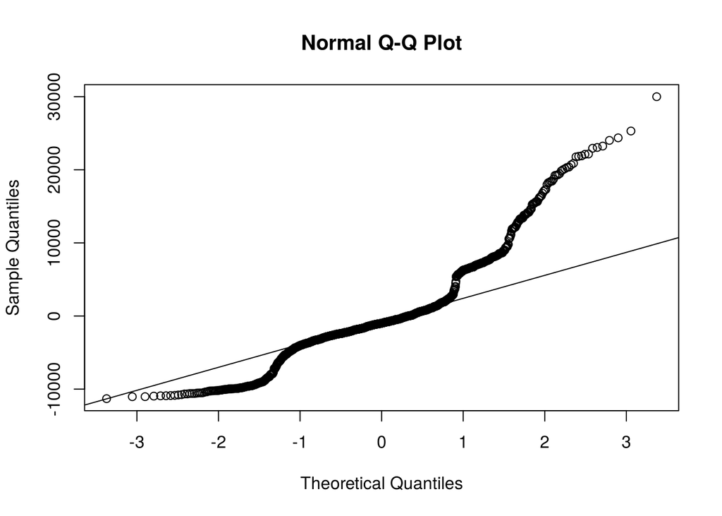

```r
qqnorm(residuals(model))
qqline(residuals(model))
```

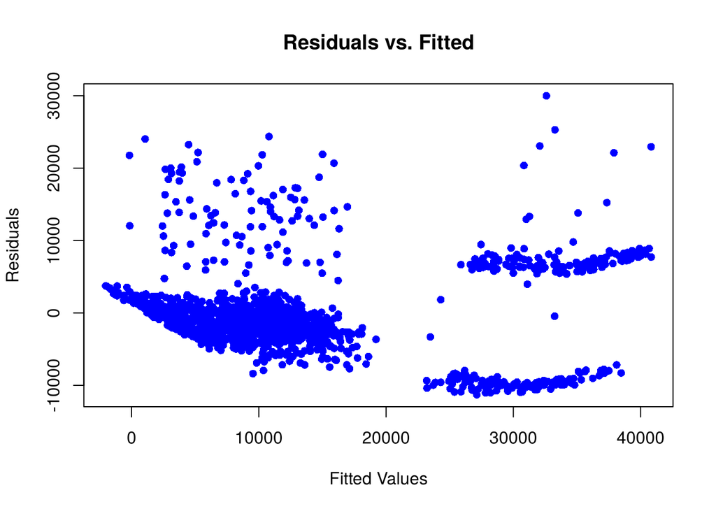

```r
plot(fitted(model), residuals(model), col = "blue", pch = 16,
     main = "Residuals vs. Fitted", xlab = "Fitted Values", ylab = "Residuals")
```

We can also try removing variables that are not significant in our regression. Note that region is one variable with three dummy columns, so it should be tested as a whole rather than column by column. An F-test comparing the models with and without sex and region does this:

```r
model_new <- lm(charges ~ age + bmi + children + smoker, data = data2)
summary(model_new)
```

```
##
## Call:
## lm(formula = charges ~ age + bmi + children + smoker, data = data2)
##
## Residuals:
##      Min       1Q   Median       3Q      Max
## -11897.9  -2920.8   -986.6   1392.2  29509.6
##
## Coefficients:
##              Estimate Std. Error t value Pr(>|t|)
## (Intercept) -12102.77     941.98 -12.848  < 2e-16 ***
## age            257.85      11.90  21.675  < 2e-16 ***
## bmi            321.85      27.38  11.756  < 2e-16 ***
## children       473.50     137.79   3.436 0.000608 ***
## smokeryes    23811.40     411.22  57.904  < 2e-16 ***
## ---
## Signif. codes:  0 '***' 0.001 '**' 0.01 '*' 0.05 '.' 0.1 ' ' 1
##
## Residual standard error: 6068 on 1333 degrees of freedom
## Multiple R-squared:  0.7497, Adjusted R-squared:  0.7489
## F-statistic: 998.1 on 4 and 1333 DF,  p-value: < 2.2e-16
```

```r
anova(model_new, model)
```

|  | Res.Df | RSS | Df | Sum of Sq | F | Pr(>F) |
| --- | --- | --- | --- | --- | --- | --- |
| 1 | 1333 | 49078450117 | NA | NA | NA | NA |
| 2 | 1329 | 48839532844 | 4 | 238917273 | 1.625328 | 0.1654002 |

The F-test’s p-value is above 0.05, so dropping sex and region together doesn’t make this model significantly worse.

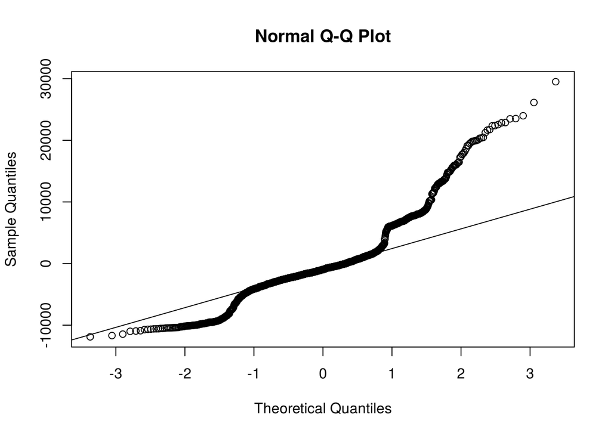

```r
qqnorm(residuals(model_new))
qqline(residuals(model_new))
```

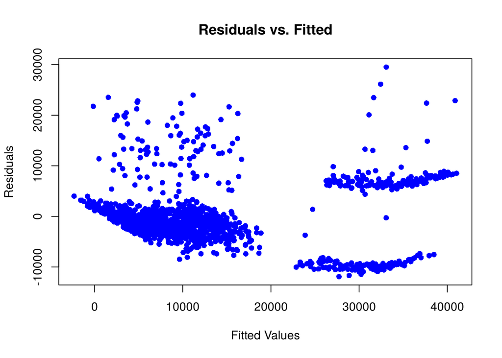

```r
plot(fitted(model_new), residuals(model_new), col = "blue", pch = 16,
     main = "Residuals vs. Fitted", xlab = "Fitted Values", ylab = "Residuals")
```

From our Q-Q plot, we can see that the residuals are not normal. The residuals vs fitted plot shows separate bands and a large gap rather than a random cloud. That pattern means the model is missing something, not just that the errors are unusual. One common response is to transform charges:

```r
data2$log_charges <- log(data2$charges + 1)  # we add 1 here to handle zero values
model_transformed <- lm(log_charges ~ age + bmi + children + smoker, data = data2)
summary(model_transformed)
```

```
##
## Call:
## lm(formula = log_charges ~ age + bmi + children + smoker, data = data2)
##
## Residuals:
##      Min       1Q   Median       3Q      Max
## -1.11293 -0.19878 -0.04690  0.07199  2.07550
##
## Coefficients:
##              Estimate Std. Error t value Pr(>|t|)
## (Intercept) 6.9833007  0.0697095 100.177  < 2e-16 ***
## age         0.0347752  0.0008804  39.501  < 2e-16 ***
## bmi         0.0106097  0.0020260   5.237  1.9e-07 ***
## children    0.1011668  0.0101970   9.921  < 2e-16 ***
## smokeryes   1.5430708  0.0304314  50.706  < 2e-16 ***
## ---
## Signif. codes:  0 '***' 0.001 '**' 0.01 '*' 0.05 '.' 0.1 ' ' 1
##
## Residual standard error: 0.449 on 1333 degrees of freedom
## Multiple R-squared:  0.7622, Adjusted R-squared:  0.7615
## F-statistic:  1068 on 4 and 1333 DF,  p-value: < 2.2e-16
```

Our new Q-Q plot:

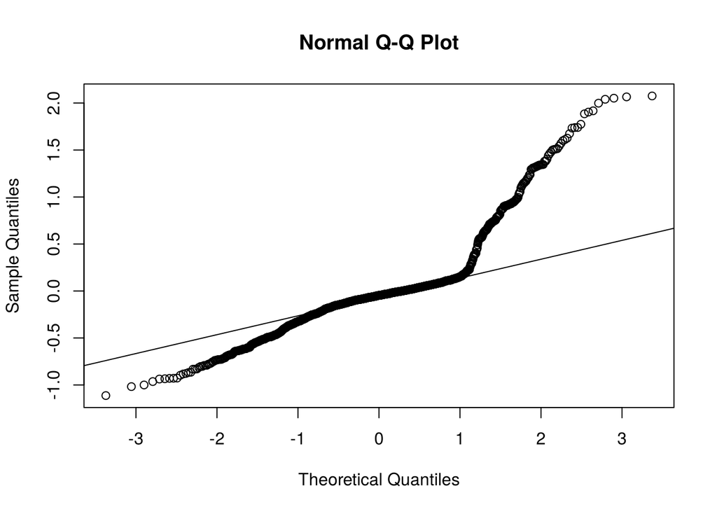

```r
residuals_log_model <- residuals(model_transformed)
qqnorm(residuals_log_model)
qqline(residuals_log_model)
```

We can still see deviation from normality even with the log transform.

```r
library(e1071)
skewness(residuals_log_model)
```

```
## [1] 1.603566
```

```r
kurtosis(residuals_log_model)
```

```
## [1] 4.176954
```

A skewness of about 1.6 and an excess kurtosis of about 4.2 mean the residuals are not symmetric and have heavy tails. Robust regression (`rlm`) is one response. It is not a transformation: it gives less weight to observations with large residuals, so a few extreme charges have less influence on the fit:

```r
library(MASS)
model_robust <- rlm(log_charges ~ age + bmi + children + smoker, data = data2)
summary(model_robust)
```

```
##
## Call: rlm(formula = log_charges ~ age + bmi + children + smoker, data = data2)
## Residuals:
##       Min        1Q    Median        3Q       Max
## -1.001491 -0.094431  0.008678  0.088874  2.282969
##
## Coefficients:
##             Value    Std. Error t value
## (Intercept)   6.9426   0.0287   241.5169
## age           0.0399   0.0004   109.8219
## bmi           0.0030   0.0008     3.5578
## children      0.1022   0.0042    24.3038
## smokeryes     1.5713   0.0125   125.2121
##
## Residual standard error: 0.1347 on 1333 degrees of freedom
```

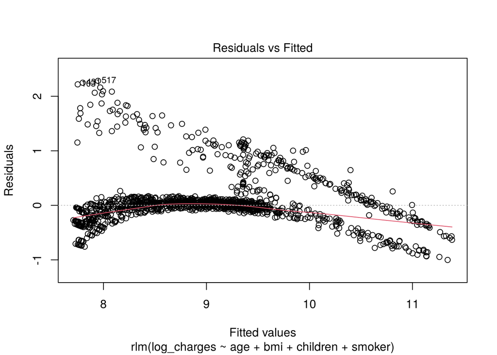

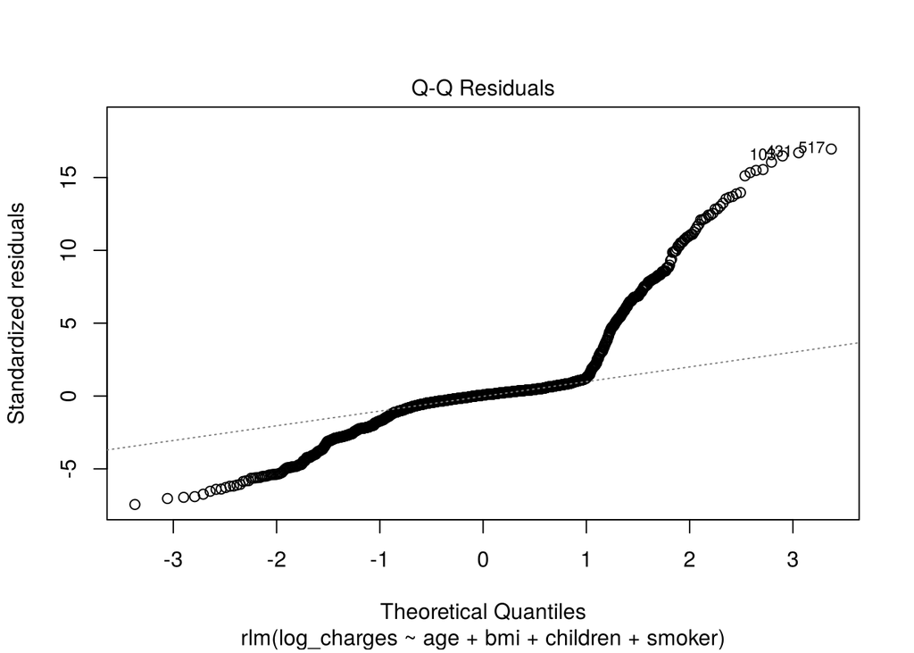

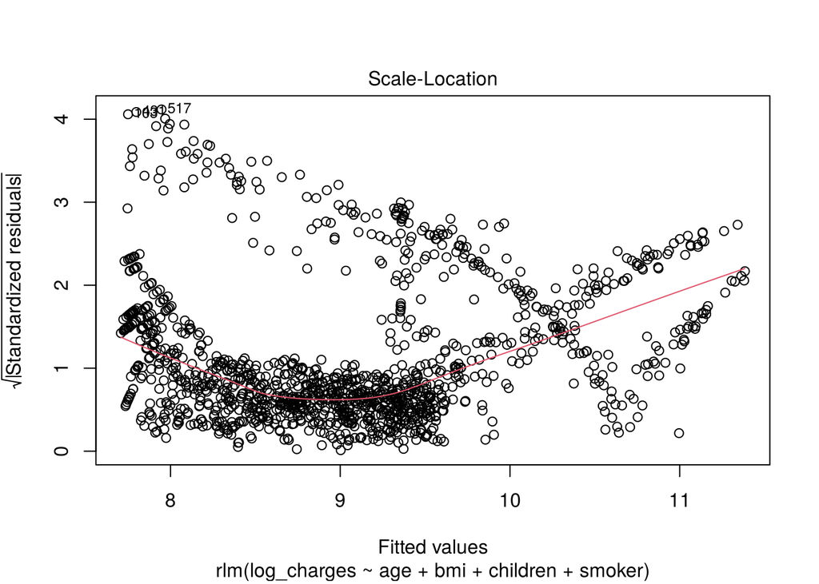

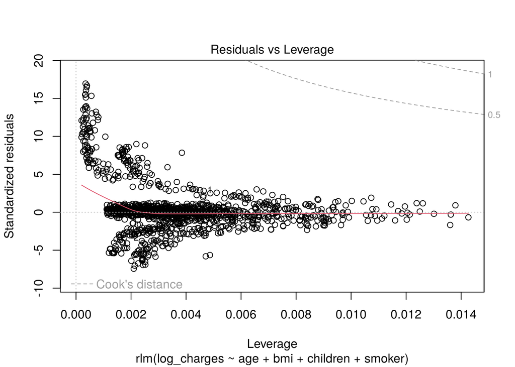

```r
plot(model_robust)
```